# rEDM Primer

Hao Ye & Ethan White

2019-11-07

## Data

We’ll model and forecast abundance data for *Dipodomys ordii*.

```r
library(ggplot2)
library(dplyr)
library(portalr)
library(rEDM)
```

- Download the data

```r
rodent_data = abundance()
```

```
## Loading in data version 1.115.0
```

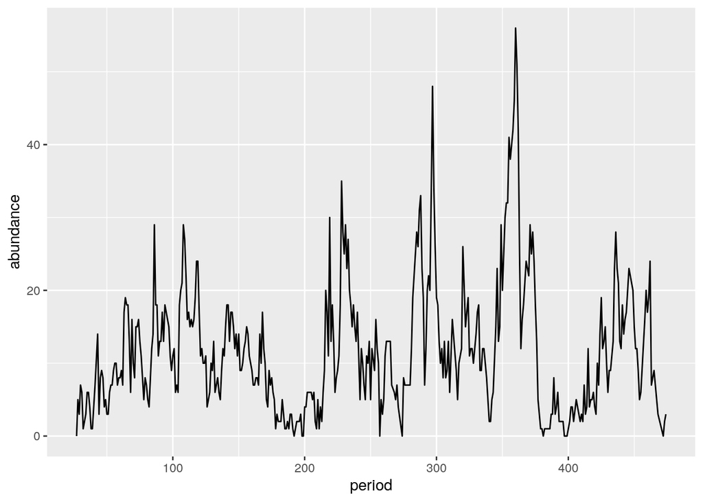

```r
do_data = data.frame(period = rodent_data$period, abundance = rodent_data$DO)

ggplot(do_data, aes(x = period, y = abundance)) +
  geom_line()
```

## Theory

- Multi-species system
- Population dynamics model would have ~10 state variables (abundance of each species)
- Each at *t* time steps
- If deterministic those 10 values at time *t+1* are fully determined by the values at *t*
- Can write this as:

$$\bar{x}(t+1) = F \left(\bar{x}(t)\right)$$

- Could assume some parametric shape (e.g., logistic growth):

$$\begin{align*}
x_1(t+1) &= r_1 x_1(t) \left[1 - x_1(t) - \alpha_{1,2} x_2(t)\right]\\
x_2(t+1) &= r_2 x_2(t) \left[1 - x_2(t) - \alpha_{2,1} x_1(t)\right]
\end{align*}$$
with parameters $r_1, r_2, \alpha_{1,2}, \alpha_{2,1}$.

- But we might get the form wrong
- And there are typically way more than 2 species even if we’re only studying 2

## Empirical Dynamic Modeling

- Model arbitrarily complex *F*
- Can capture the complexity of a multiple species/state system in a single species/state time-series
- Does this based on Taken’s Theorem
  - Resconstruct a shadow of the real system from single time-series

In other words, instead of relying on:
$$x_i(t+1) = F_i\left(x_1(t), x_2(t), \dots, x_d(t)\right)$$

the system dynamics can be represented as a function of a single variable and its lags:
$$x_i(t+1) = G_i\left(x_i(t), x_i(t-1), \dots, x_i(t-(E-1))\right)$$

- $E$ is the embedding dimension which defines how far back in time we go

## Usage

- Need to estimate $G_i$ from the data
- Typically think of this as fitting an equation, but $G$ is arbitrarily complex
- And since we’re focusing on prediction we don’t need the equation, we just need to know what is going to happen next
- And we can get this prediction by looking through the existing time-series and finding periods that look like the current period (*draw example*)
- These historical periods should reflect the same dynamics of $G$ and therefore the same state variables in $F$
- Which should mean that what happens next in these periods should match what happens next now.
- Use the simplest, simplex projection
- Weighted nearest-neighbors approximation:
1. Have value of $x$ and its lags at time $t$. Then we want a prediction of $x(t+1) = G\left(x(t), x(t-1), \dots, x(t - (E-1))\right)$.
2. We look for $j = 1..k$ nearest neighbors in the observed time series such that $\langle x(t), x(t-1), \dots, x(t - (E-1))\rangle \approx \langle x(n_j), x(n_j-1), \dots, x(n_j - (E-1))\rangle$.
3. We then suppose that $x(t+1) \approx x(n_j+1)$.
- Use a distance function to judge how similar $\langle x(t), x(t-1), \dots, x(t - (E-1))\rangle$ is to $\langle x(n_j), x(n_j-1), \dots, x(n_j - (E-1))\rangle$
- Estimating $x(t+1)$ as a weighted average of the $x(n_j+1)$ values with weighting determined by the distances.

## Determining Embedding Dimension

- Need to know `E`, how many lags to use for determining if time-series is similar
- Split the data to reserve some for forecasting

```r
library(rEDM)                    # load the package

n <- nrow(do_data)
lib <- c(1, floor(2/3 * n))      # indices for the first 2/3 of the time series
pred <- c(floor(2/3 * n) + 1, n) # indices for the final 1/3 of the time series
```

- Fit 10 different embedding dimensions (1:10) see how well they work

```r
simplex(do_data,                     # input data (for data.frames, uses 2nd column)
        lib = lib, pred = lib,   # which portions of the data to train and predict
        E = 1:10)                # embedding dimensions to try
```

```
##     E tau tp nn num_pred       rho      mae     rmse perc        p_val
## 1   1   1  1  2      275 0.7358245 3.659879 5.140658    1 1.183931e-54
## 2   2   1  1  3      274 0.7021262 4.044757 5.554850    1 5.610628e-47
## 3   3   1  1  4      273 0.7302235 3.875454 5.234599    1 6.207907e-53
## 4   4   1  1  5      272 0.7378430 3.724003 5.109220    1 1.459309e-54
## 5   5   1  1  6      271 0.7662751 3.555201 4.851949    1 7.399084e-62
## 6   6   1  1  7      270 0.7665337 3.444734 4.848684    1 1.042904e-61
## 7   7   1  1  8      269 0.7600007 3.517322 4.906595    1 1.157592e-59
## 8   8   1  1  9      268 0.7524314 3.485707 4.998275    1 1.980344e-57
## 9   9   1  1 10      267 0.7334681 3.567860 5.158536    1 1.487197e-52
## 10 10   1  1 11      266 0.7330981 3.610751 5.171250    1 2.814627e-52
##    const_pred_num_pred const_pred_rho const_pred_mae const_pred_rmse
## 1                  275      0.7984610       3.421818        4.772268
## 2                  274      0.7982366       3.416058        4.771417
## 3                  273      0.7977041       3.421245        4.778615
```

[output cut: 18 more lines]

- Output shows how well the model “predicted” on the given data
- Focus on measures of fit/error:
  - rho (correlation between observed and predicted values)
  - mae (mean absolute error)
  - rmse (root mean squared error)
- `E` of 5 or 6 is optimal
- Use 5 for simpler model
- Use to forecast the remaining 1/3 of the data.

## Forecasts

- Similar code for forecasting for the last 1/3 of the time series
- To store predicted values add `stats_only` argument

```r
  output <- simplex(do_data,
          lib = lib, pred = pred,  # predict on last 1/3
          E = 5,
          stats_only = FALSE)      # return predictions, too
```

- Output is a data.frame with a list column for the predictions

```r
predictions <- output[[1]]$model_output
str(predictions)
```

```
## 'data.frame':    415 obs. of  4 variables:
##  $ time    : num  28 29 30 31 32 33 34 35 36 37 ...
##  $ obs     : num  5 3 7 6 1 2 3 6 6 4 ...
##  $ pred    : num  NaN NaN NaN NaN NaN NaN NaN NaN NaN NaN ...
##  $ pred_var: num  NaN NaN NaN NaN NaN NaN NaN NaN NaN NaN ...
```

- Plot the predictions against the original data

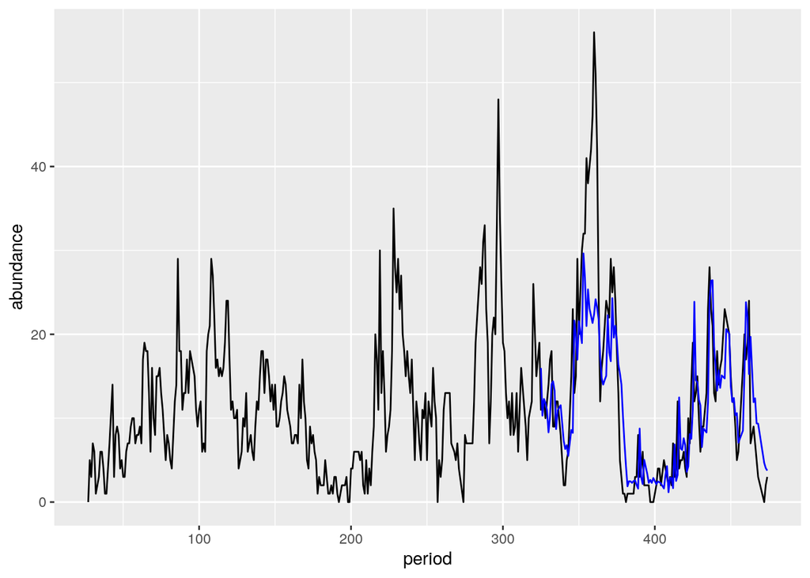

```r
ggplot(do_data, aes(x = period, y = abundance)) +
  geom_line() +
  geom_line(data = predictions, mapping = aes(x = time, y = pred), color = 'blue')
```

- Also have estimate of the prediction uncertainty in `pred_var`
- Variance of the prediction
- Plot a 95% prediction interval use $\pm 2 * SD$

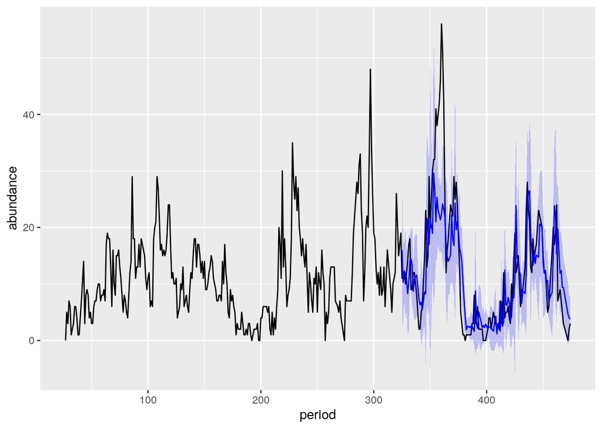

```r
ggplot(do_data, aes(x = period, y = abundance)) +
  geom_line() +
  geom_line(data = predictions, mapping = aes(x = time, y = pred), color = 'blue') +
  geom_ribbon(data = predictions,
              mapping = aes(x = time,
                            y = pred,
                            ymax = pred + 2 * sqrt(pred_var),
                            ymin = pred - 2 * sqrt(pred_var)),
              fill = 'blue',
              alpha = 0.2)
```

- This is a single time step forecast
- For multi-step forecasts we can take these one step ahead forecasts along with their uncertainties and increment forward for multi-step forecasts as you’ll see later in the week in a different context.
- Or we can train the model to make forecasts the number of steaps head that we want
- We do this using `tp`

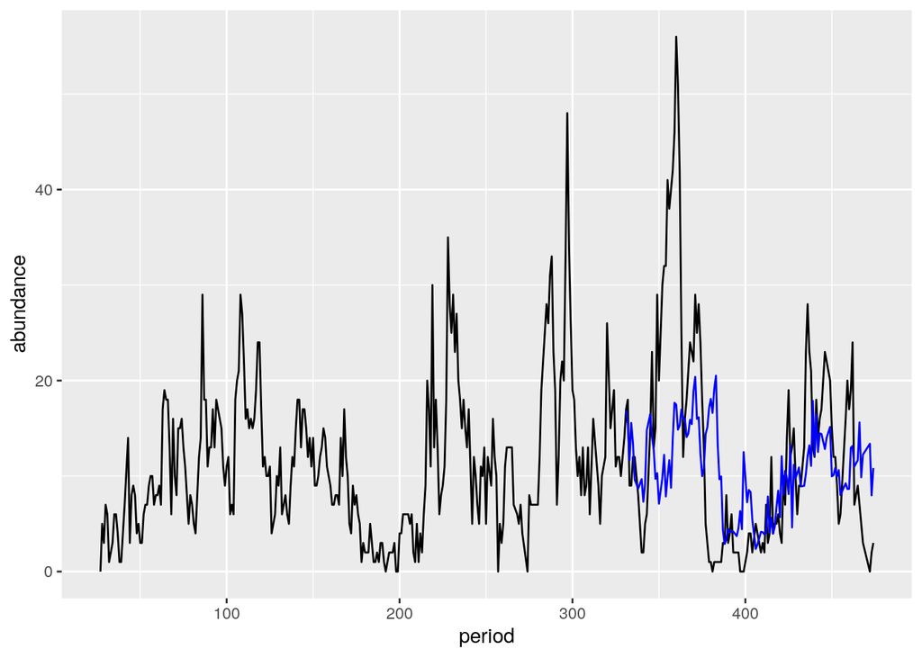

```r
output <- simplex(do_data,
          lib = lib, pred = pred,  # predict on last 1/3
          E = 6,
          tp = 6,
          stats_only = FALSE)      # return predictions, too

predictions <- output[[1]]$model_output

ggplot(do_data, aes(x = period, y = abundance)) +
  geom_line() +
  geom_line(data = predictions, mapping = aes(x = time, y = pred), color = 'blue')
```

- The model performs less well the longer the “forecast horizon” or distance into the future we ask it to prediction, which is a common feature of real world forecasts.